# BJ_Reviews

1. Introduction
2. What is Sentiment Analysis
3. Problem Statement
4. Objectives of Project
5. Data Collection
6. Data Cleaning
7. Data Exploration
8. Creating 'Sentiment' Columns
9. Data Analysis: Story Generation and Visualization from Reviews
10. Conclusion

# 1) Introduction

BJ’s offers a wide range of options and when there are a lot of options for everyone to choose from, it can be hard to narrow down what the customer wants. This is both a bit scary on both the customer and restaurant side because as a worker, you are trying to satisfy the customer needs, but the customer does not know the extent to which they will enjoy the service and food from the restaurant. Workers can’t always predict or know what the customer wants, so through the use of analyzing reviews, it can help them know what type of customers are coming and what they like based on their personal preference. Reviews from customers are vital for BJ’s success because it can help them improve on areas that need to be better or even know what they should keep continuing to have to keep their customers happy and satisfied. In order for BJ’s to keep growing and expanding, one important factor is to further analyze these reviews through the use of Natural Language Processing (NLP) technology and sentiment analysis. Through the use of NLP, we aim to turn the sentiments from the reviews into actionable and visualization insights.

# 2) What is Sentiment Analysis?

Sentiment analysis is a natural language processing technique that involves analyzing text to determine the sentiment or emotion expressed within it. By examining the words and phrases used in a piece of text, sentiment analysis algorithms can classify the overall sentiment as positive, negative, or neutral. Sentiment analysis is vital for businesses as it helps them understand customer sentiment from reviews and feedback. By analyzing the emotions behind the words, businesses can gain valuable insights into customer satisfaction, identify areas for improvement, and track the impact of marketing campaigns or product launches. This enables businesses to respond effectively to customer needs, enhance the customer experience, and ultimately improve brand reputation and loyalty.

# 3) Problem Statement

# 4) Objectives of the Project

#### Dataset Details

The file includes: Customer_Name, Rating, Review_Date, Review

#### Customer_Name: The name of the customer who left the review.

#### Rating: The rating score from 1 to 5 given by each customer.

#### Review_Date: The date when the review was posted.

#### Review: The open-ended reviews by each customer.

# 5) Data Collection

#### The following are the steps taken to collect the data for our BJ's Yelp review dataset.

### a) Download this chrome extension to your browser.

[figure not shown]

### b) Go to BJ's Yelp Reviews and Open the Extension

## c. Click the 'CSV' to scrape all the reviews for the page

[figure not shown]

### d. Repeat this process for the remaining pages of reviews

### e. Here is what the resulting CSV file looks like from one page of reviews:

[figure not shown]

### Note: The extension did not extract the ratings, so I filtered by rating and collected and separated the reviews by rating.

### f. Compiling all of the reviews

I then sorted the all of scraped data into folders by rating.

[figure not shown]

I then used the following code to merge all of the 1 star reviews

```python
import os
import pandas as pd

# Folder path containing CSV files on your desktop
desktop_path = os.path.expanduser("~/Desktop")
folder_path = os.path.join(desktop_path, "1 star")

# List all CSV files in the folder
csv_files = [file for file in os.listdir(folder_path) if file.endswith('.csv')]

# Combine all CSV files into a single DataFrame
combined_df = pd.concat([pd.read_csv(os.path.join(folder_path, file)) for file in csv_files])

# Save the combined DataFrame to a new CSV file on your desktop
output_file = os.path.join(desktop_path, 'combined.csv')
combined_df.to_csv(output_file, index=False)
```

Below is what the resulting csv file looks like. I then manually inserted a rating column and inputed the matching rating.

[figure not shown]

### I then repeated this process for the other ratings

### g. Combining all CSV files into a master dataset

Finally, I used this code to combine the reviews

```python
import os
import pandas as pd

# Folder path containing CSV files on your desktop
desktop_path = os.path.expanduser("~/Desktop")
folder_path = os.path.join(desktop_path, "reviews")

# List all CSV files in the folder
csv_files = [file for file in os.listdir(folder_path) if file.endswith('.csv')]

# Combine all CSV files into a single DataFrame
combined_df = pd.concat([pd.read_csv(os.path.join(folder_path, file)) for file in csv_files])

# Save the combined DataFrame to a new CSV file on your desktop
output_file = os.path.join(desktop_path, 'BJ_Reviews.csv')
combined_df.to_csv(output_file, index=False)
```

#### Here is what the CSV looks like in excel:

[figure not shown]

In this section, we collected Yelp Review of BJ's Stockton location. This was done through using a chrome extension to collect the raw data, followed by compiling the csv files together using code. Additionally, the ratings were added manually through excel after distinguishing the reviews into separated files.

# 6) Data Cleaning

```python
import pandas as pd

# Load the dataset into a DataFrame
df = pd.read_csv('BJ_Reviews.csv')

# Display the first few rows of the dataset as a table
display(df.head(10))
```

|  | Customer_Name | Rating | Review_Date | Review |
| --- | --- | --- | --- | --- |
| 0 | Tray N. | 1 | 29-Sep-23 | Horrrrible, horrible and they don't even answe... |
| 1 | Ashley N. | 1 | 16-Sep-23 | Great lunch prices and clean facilities. But t... |
| 2 | Antoinette B. | 1 | 11-Sep-23 | Current experience today. My boyfriend and I w... |
| 3 | Anita R. | 1 | 8-Aug-23 | I was at BJ'S in Stockton, Ca. 08/06 and found... |
| 4 | Lydia E. | 1 | 13-Jul-23 | Everytime I eat here, it's always disappointin... |
| 5 | Lordee T. | 1 | 1-Jul-23 | We can see why Stockton ratings are so low. Po... |
| 6 | Maleni P. | 1 | 28-Jun-23 | Super disappointed with the management and foo... |
| 7 | Beth F. | 1 | 14-Jun-23 | Very disappointed..... I ordered my normal. T... |
| 8 | Lisa M. | 1 | 4-Jun-23 | Okay so service today was terrible! We receiv... |
| 9 | Rebecca S. | 1 | 26-May-23 | I understand that places can be very busy, esp... |

#### Using Jupyter Notebook, we can see that the csv file contains the customer names, ratings, review dates, and the detailed review. Additionally, this code lets us see the first few rows of our dataset to get an idea of what it looks like before cleaning.

### Checking for missing values and data types:

```python
# Check the data types and missing values
print(df.info())
```

```
<class 'pandas.core.frame.DataFrame'>
RangeIndex: 939 entries, 0 to 938
Data columns (total 4 columns):
 #   Column         Non-Null Count  Dtype
---  ------         --------------  -----
 0   Customer_Name  939 non-null    object
 1   Rating         939 non-null    int64
 2   Review_Date    939 non-null    object
 3   Review         939 non-null    object
dtypes: int64(1), object(3)
memory usage: 29.5+ KB
None
```

#### Here we can see the data types of our dataset and they are mostly objects because they contain string values. Rating is an integer value. "Review_Date" is of data type object, which usually indicates it contains string values. However, based on the name, it likely represents dates and could be converted to a datetime data type for better handling. We can also see that the data has no misssing values.

### Summary statistics of numerical columns:

```python
# Summary statistics for numerical columns
print(df.describe())
```

```
           Rating
count  939.000000
mean     2.905218
std      1.496465
min      1.000000
25%      1.000000
50%      3.000000
75%      4.000000
max      5.000000
```

#### Here we can see that the dataset contains 939 ratings and the average rating for this specific BJ's location is 2.9 stars on Yelp.

### Checking for outliers:

```python
# Check for outliers (assuming numerical columns)
numeric_columns = df.select_dtypes(include=['int64', 'float64'])
outliers = pd.DataFrame(columns=['Column', 'Outliers'])
for column in numeric_columns.columns:
    q1 = df[column].quantile(0.25)
    q3 = df[column].quantile(0.75)
    iqr = q3 - q1
    lower_bound = q1 - 1.5 * iqr
    upper_bound = q3 + 1.5 * iqr
    outliers_count = len(df[(df[column] < lower_bound) | (df[column] > upper_bound)])
    outliers = outliers.append({'Column': column, 'Outliers': outliers_count}, ignore_index=True)

print("\nOutliers:")
print(outliers)
```

```
Outliers:
   Column Outliers
0  Rating        0
```

#### Here we can see that the dataset contains no outliers among the ratings. This is good so that there are no extreme values that will skew the data.

### Checking for duplicates in the dataset:

```python
# Check for duplicate records
duplicate_rows = df[df.duplicated()]
print("\nDuplicate Rows:")
print(duplicate_rows)
```

```
Duplicate Rows:
Empty DataFrame
Columns: [Customer_Name, Rating, Review_Date, Review]
Index: []
```

#### Here we can see that there are no duplicates in the dataset.

### Checking and removing text errors in the reviews column:

```python
import pandas as pd
import re

# Load the dataset into a DataFrame
df = pd.read_csv('BJ_Reviews.csv')

# Function to clean reviews
def clean_review(text):
    # Lowercase the text
    text = text.lower()
    # Remove brackets and their contents
    text = re.sub(r'\[.*?\]', '', text)
    # Remove numbers in words
    text = re.sub(r'\b(one|two|three|four|five|six|seven|eight|nine|ten)\b', '', text)
    # Remove punctuation
    text = re.sub(r'[^\w\s]', '', text)
    return text

# Apply cleaning function to the 'Review' column
df['Review'] = df['Review'].apply(clean_review)

# Display the first few rows of the cleaned dataset
display(df.head(10))
```

|  | Customer_Name | Rating | Review_Date | Review |
| --- | --- | --- | --- | --- |
| 0 | Tray N. | 1 | 29-Sep-23 | horrrrible horrible and they dont even answer ... |
| 1 | Ashley N. | 1 | 16-Sep-23 | great lunch prices and clean facilities but th... |
| 2 | Antoinette B. | 1 | 11-Sep-23 | current experience today my boyfriend and i we... |
| 3 | Anita R. | 1 | 8-Aug-23 | i was at bjs in stockton ca 0806 and found a p... |
| 4 | Lydia E. | 1 | 13-Jul-23 | everytime i eat here its always disappointinga... |
| 5 | Lordee T. | 1 | 1-Jul-23 | we can see why stockton ratings are so low poo... |
| 6 | Maleni P. | 1 | 28-Jun-23 | super disappointed with the management and foo... |
| 7 | Beth F. | 1 | 14-Jun-23 | very disappointed i ordered my normal the veg... |
| 8 | Lisa M. | 1 | 4-Jun-23 | okay so service today was terrible we receive... |
| 9 | Rebecca S. | 1 | 26-May-23 | i understand that places can be very busy espe... |

#### Cleaning the 'Review' column with this code makes its formating consistent between reviews and suitable for analysis.

# 7) Data Exploration

```python
import pandas as pd
from collections import Counter
import re
import nltk
from nltk.tokenize import word_tokenize
from nltk.corpus import stopwords

# Load the dataset
df = pd.read_csv('BJ_Reviews.csv')

# Concatenate all reviews into a single text
all_reviews = ' '.join(df['Review'])

# Tokenize the text into words
words = word_tokenize(all_reviews)

# Remove stopwords and non-alphabetic tokens
stop_words = set(stopwords.words('english'))
filtered_words = [word.lower() for word in words if word.isalpha() and word.lower() not in stop_words]

# Count the frequency of each word
word_counts = Counter(filtered_words)

# Get the most common words
most_common_words = word_counts.most_common(10)  # Change the number to get more or fewer words

# Create a DataFrame for the most common words
common_words_df = pd.DataFrame(most_common_words, columns=['Word', 'Count'])

# Display the most common words as a table
print("Most common words:")
display(common_words_df)
```

```
Most common words:
```

|  | Word | Count |
| --- | --- | --- |
| 0 | food | 864 |
| 1 | service | 620 |
| 2 | good | 544 |
| 3 | us | 473 |
| 4 | time | 420 |
| 5 | great | 392 |
| 6 | get | 374 |
| 7 | order | 357 |
| 8 | bj | 345 |
| 9 | came | 343 |

#### This code returns the most common words among the reviews. These common words provide insights into the sentiments expressed by customers in their reviews of BJ's restaurant. They can highlight the areas of interest or concern that customers frequently mention, such as food quality, service experiences, overall satisfaction, and specific actions or interactions during their visit after further analysis.

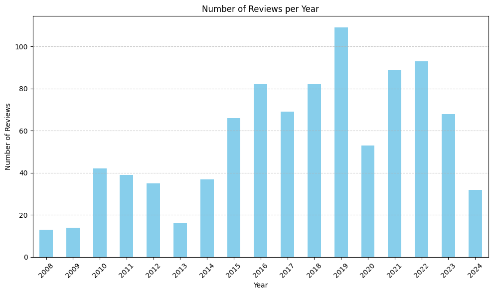

```python
import pandas as pd
import matplotlib.pyplot as plt

# Load the dataset
df = pd.read_csv('BJ_Reviews.csv')

# Convert 'Review_Date' column to datetime format
df['Review_Date'] = pd.to_datetime(df['Review_Date'])

# Extract the year from the 'Review_Date' column
df['Year'] = df['Review_Date'].dt.year

# Count the number of reviews per year
reviews_per_year = df['Year'].value_counts().sort_index()

# Plotting the bar chart
plt.figure(figsize=(10, 6))
reviews_per_year.plot(kind='bar', color='skyblue')
plt.title('Number of Reviews per Year')
plt.xlabel('Year')
plt.ylabel('Number of Reviews')
plt.xticks(rotation=45)
plt.grid(axis='y', linestyle='--', alpha=0.7)
plt.tight_layout()
plt.show()
```

#### Here we can see the trend of reviews over the years for this specific BJ's location. It looks like the location had a significant increase in reviews following 2015 and reached a peak in 2019. 2020 may have been a hard year to get customerss due to the COVID-19 pandemic. Additionally, in 2024 their review count has hit a low point in comparison to more recent years but this may be due to it still being early in the year.

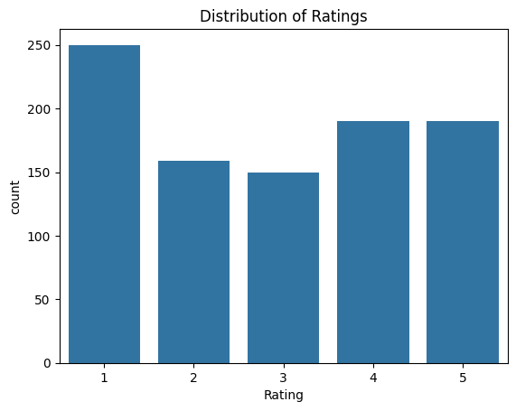

```python
# Distribution of ratings
import seaborn as sns

sns.countplot(x='Rating', data=df)
plt.title('Distribution of Ratings')
plt.show()
```

#### Here we have a visual of the distribution of ratings, with a significant amount of ratings being 1 star reviews. This could suggest that the specific location is struggling to provide a satsifying experience for its customer base.

# 8) Creating 'Sentiment' Columns

Creating the sentiment columns is a vital step in Milestone 1. This is a process that produces the outcome of the review (its sentiment) as a label (positive, negative, and neutral). This process also produces the sentiment score which is calculated based on the intensity of sentiment expressed in the review text, providing a quantitative measure of sentiment strength.

```python
import pandas as pd
import nltk
from nltk.sentiment import SentimentIntensityAnalyzer

# Download the VADER lexicon for sentiment analysis
nltk.download('vader_lexicon')

# Initialize the VADER sentiment analyzer
sid = SentimentIntensityAnalyzer()

def analyze_sentiment(text):
    # Analyzes the sentiment of the given text using VADER sentiment analyzer.
    # Returns a dictionary containing the compound sentiment score.
    sentiment_scores = sid.polarity_scores(text)
    return sentiment_scores

def interpret_sentiment(sentiment_scores):
    # Interprets the sentiment score and returns a sentiment label.
    compound_score = sentiment_scores['compound']
    if compound_score >= 0.05:
        return 'Positive'
    elif compound_score <= -0.05:
        return 'Negative'
    else:
        return 'Neutral'

# Load the dataset into a DataFrame
df = pd.read_csv('BJ_reviews.csv')

# Perform sentiment analysis for each text entry in the dataset
sentiment_labels = []
for text in df['Review']:
    sentiment_scores = analyze_sentiment(text)
    sentiment_label = interpret_sentiment(sentiment_scores)
    sentiment_labels.append(sentiment_label)

# Add the sentiment labels to the dataframe as a new column
df['Sentiment'] = sentiment_labels

# Save the DataFrame with the sentiment column to a new CSV file
df.to_csv('BJ_reviews_with_sentiment.csv', index=False)

display(df.head())
```

|  | Customer_Name | Rating | Review_Date | Review | Sentiment |
| --- | --- | --- | --- | --- | --- |
| 0 | Tray N. | 1 | 29-Sep-23 | Horrrrible, horrible and they don't even answe... | Negative |
| 1 | Ashley N. | 1 | 16-Sep-23 | Great lunch prices and clean facilities. But t... | Negative |
| 2 | Antoinette B. | 1 | 11-Sep-23 | Current experience today. My boyfriend and I w... | Positive |
| 3 | Anita R. | 1 | 8-Aug-23 | I was at BJ'S in Stockton, Ca. 08/06 and found... | Positive |
| 4 | Lydia E. | 1 | 13-Jul-23 | Everytime I eat here, it's always disappointin... | Positive |

```python
import pandas as pd
import nltk
from nltk.sentiment import SentimentIntensityAnalyzer

# Download the VADER lexicon for sentiment analysis
nltk.download('vader_lexicon')

# Initialize the VADER sentiment analyzer
sid = SentimentIntensityAnalyzer()

def analyze_sentiment(text):
    # Analyzes the sentiment of the given text using VADER sentiment analyzer.
    # Returns a dictionary containing the compound sentiment score.
    sentiment_scores = sid.polarity_scores(text)
    return sentiment_scores

def interpret_sentiment(sentiment_scores):
    # Interprets the sentiment score and returns a sentiment label.
    compound_score = sentiment_scores['compound']
    if compound_score >= 0.05:
        return 'Positive'
    elif compound_score <= -0.05:
        return 'Negative'
    else:
        return 'Neutral'

# Change the directory to the one you've been using previously
# Load the dataset into a DataFrame
df = pd.read_csv('BJ_reviews.csv')

# Perform sentiment analysis for each text entry in the dataset
sentiment_scores_list = []
sentiment_labels = []
for text in df['Review']:
    sentiment_scores = analyze_sentiment(text)
    sentiment_label = interpret_sentiment(sentiment_scores)
    sentiment_scores_list.append(sentiment_scores['compound'])  # Append compound score
    sentiment_labels.append(sentiment_label)

# Add the sentiment labels and scores to the dataframe
df['Sentiment_Score'] = sentiment_scores_list
df['Sentiment'] = sentiment_labels

# Save the DataFrame with sentiment analysis results to a new CSV file
df.to_csv('BJ_reviews_with_sentiment.csv', index=False)

display(df)
```

|  | Customer_Name | Rating | Review_Date | Review | Sentiment_Score | Sentiment |
| --- | --- | --- | --- | --- | --- | --- |
| 0 | Tray N. | 1 | 29-Sep-23 | Horrrrible, horrible and they don't even answe... | -0.9296 | Negative |
| 1 | Ashley N. | 1 | 16-Sep-23 | Great lunch prices and clean facilities. But t... | -0.4255 | Negative |
| 2 | Antoinette B. | 1 | 11-Sep-23 | Current experience today. My boyfriend and I w... | 0.9852 | Positive |
| 3 | Anita R. | 1 | 8-Aug-23 | I was at BJ'S in Stockton, Ca. 08/06 and found... | 0.6222 | Positive |
| 4 | Lydia E. | 1 | 13-Jul-23 | Everytime I eat here, it's always disappointin... | 0.9306 | Positive |
| ... | ... | ... | ... | ... | ... | ... |
| 934 | Raisa M. | 5 | 29-Mar-24 | Christina is the reason why we come to BJS. Un... | -0.1027 | Negative |
| 935 | Volena T. | 5 | 28-Mar-24 | The food was so yummy and we absolutely adored... | 0.9795 | Positive |
| 936 | CC S. | 5 | 28-Mar-24 | I'm going to start this review by just saying ... | 0.9697 | Positive |
| 937 | Darian H. | 5 | 23-Mar-24 | Ok back at BJ , I couldn't figure out what I w... | 0.7793 | Positive |
| 938 | Sam C. | 5 | 8-Mar-24 | Kudos to Kellsie! She is an amazing waitress. ... | 0.9595 | Positive |

939 rows × 6 columns

# 9) Data-Analysis: Story Generation and Visualization from Reviews

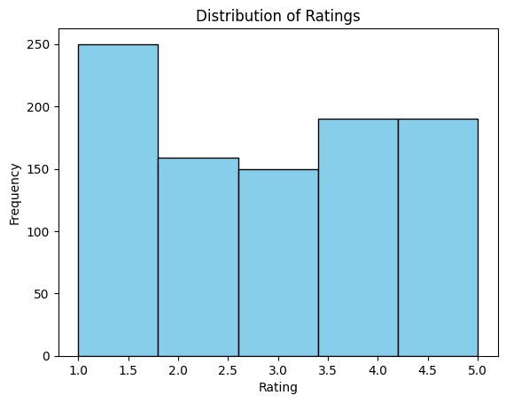

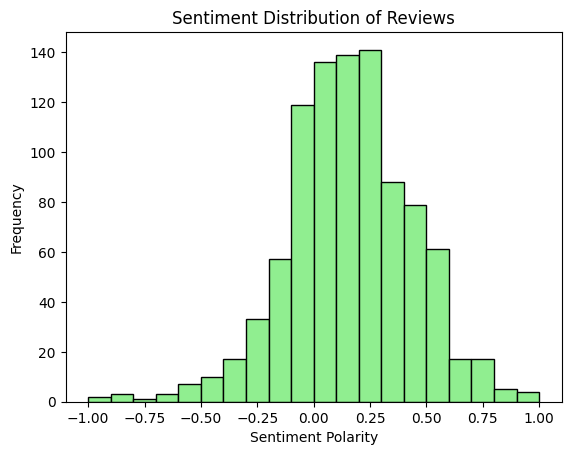

```python
from textblob import TextBlob

# Function to perform sentiment analysis in the dataset
def analyze_sentiment(text):
    analysis = TextBlob(text)
    return analysis.sentiment.polarity

# Apply sentiment analysis to 'Review' column in order to know if thee reviews are positive or negative
df['Sentiment'] = df['Review'].apply(analyze_sentiment)

import matplotlib.pyplot as plt

# Plot distribution of ratings by 1 being the lowest rating and 5  being the highest ranking
plt.hist(df['Rating'], bins=5, color='skyblue', edgecolor='black')
plt.xlabel('Rating')
plt.ylabel('Frequency')
plt.title('Distribution of Ratings')
plt.show()

# Plot sentiment distribution in order to know the distribution of the reviews by -1 being the worst review and 1 being the best review.
plt.hist(df['Sentiment'], bins=20, color='lightgreen', edgecolor='black')
plt.xlabel('Sentiment Polarity')
plt.ylabel('Frequency')
plt.title('Sentiment Distribution of Reviews')
plt.show()
```

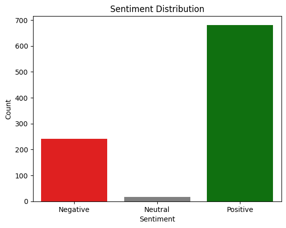

```
Positive    681
Negative    242
Neutral      16
Name: Sentiment, dtype: int64
```

```python
import pandas as pd
import matplotlib.pyplot as plt
import seaborn as sns

# Load the dataset into a DataFrame
df = pd.read_csv('BJ_reviews_with_sentiment.csv')

# Define custom colors for negative, neutral, and positive sentiments
colors = {'Negative': 'red', 'Neutral': 'grey', 'Positive': 'green'}

# Plot sentiment distribution with specified order of bars and custom colors
sns.countplot(data=df, x='Sentiment', order=['Negative', 'Neutral', 'Positive'], palette=colors.values())
plt.title('Sentiment Distribution')
plt.xlabel('Sentiment')
plt.ylabel('Count')
plt.show()

# Print unique values and counts in the 'Sentiment' column
print(df['Sentiment'].value_counts())
```

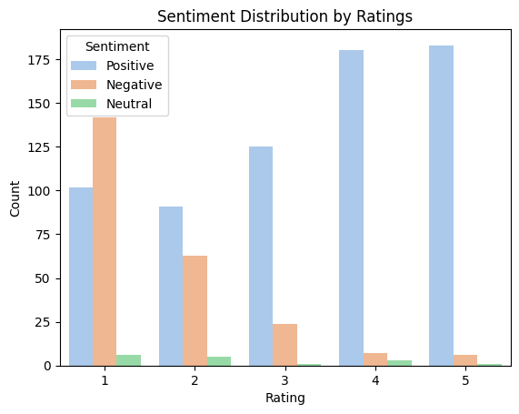

```python
# Load the dataset into a DataFrame
df = pd.read_csv('BJ_reviews_with_sentiment.csv')

# Create a new DataFrame to hold combinations of rating and sentiment
ratings = df['Rating'].unique()
sentiments = ['Positive', 'Negative', 'Neutral']

data = []
for rating in ratings:
    for sentiment in sentiments:
        count = len(df[(df['Rating'] == rating) & (df['Sentiment'] == sentiment)])
        data.append({'Rating': rating, 'Sentiment': sentiment, 'Count': count})

df_plot = pd.DataFrame(data)

# Plot sentiment distribution by ratings
sns.barplot(data=df_plot, x='Rating', y='Count', hue='Sentiment', palette='pastel')
plt.title('Sentiment Distribution by Ratings')
plt.xlabel('Rating')
plt.ylabel('Count')
plt.legend(title='Sentiment')
plt.show()
```

```
Positive    681
Negative    242
Neutral      16
Name: Sentiment, dtype: int64
   Customer_Name  Rating Review_Date  \
0        Tray N.       1  2023-09-29
1      Ashley N.       1  2023-09-16
2  Antoinette B.       1  2023-09-11
3       Anita R.       1  2023-08-08
4       Lydia E.       1  2023-07-13

                                              Review  Sentiment_Score  \
0  Horrrrible, horrible and they don't even answe...          -0.9296
1  Great lunch prices and clean facilities. But t...          -0.4255
2  Current experience today. My boyfriend and I w...           0.9852
3  I was at BJ'S in Stockton, Ca. 08/06 and found...           0.6222
4  Everytime I eat here, it's always disappointin...           0.9306

  Sentiment  Sentiment_Value  Year
0  Negative               -1  2023
1  Negative               -1  2023
2  Positive                1  2023
3  Positive                1  2023
4  Positive                1  2023
```

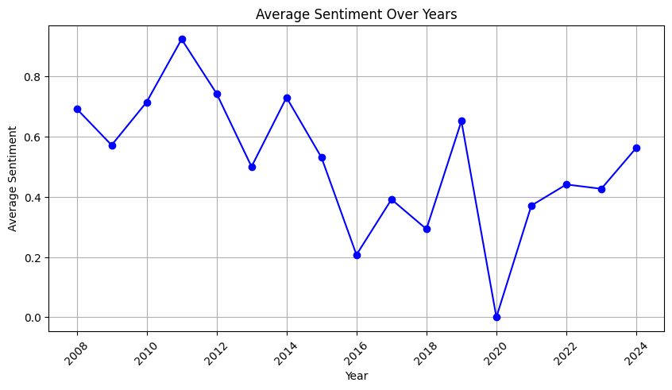

```python
import pandas as pd

# Load the dataset into a DataFrame
df = pd.read_csv('BJ_reviews_with_sentiment.csv')

# 1. Print unique values and counts in the 'Sentiment' column
print(df['Sentiment'].value_counts())

# 2. Review code for calculating average sentiment per year
# Convert 'Review_Date' column to datetime format
df['Review_Date'] = pd.to_datetime(df['Review_Date'])

# Convert sentiment categories to numerical values
df['Sentiment_Value'] = df['Sentiment'].apply(lambda x: 1 if x == 'Positive' else -1 if x == 'Negative' else 0)

# Extract year from Review_Date
df['Year'] = df['Review_Date'].dt.year

# Calculate average sentiment score for each year
yearly_sentiment = df.groupby('Year')['Sentiment_Value'].mean()

# Print the first few rows of the DataFrame to inspect the data
print(df.head())

# Plot sentiment over time (yearly average)
import matplotlib.pyplot as plt

plt.figure(figsize=(10, 5))
yearly_sentiment.plot(kind='line', marker='o', color='b', linestyle='-')
plt.title('Average Sentiment Over Years')
plt.xlabel('Year')
plt.ylabel('Average Sentiment')
plt.xticks(rotation=45)
plt.grid(True)
plt.show()
```

# 10) Conclusion

The integration of Natural Language Processing (NLP) technology and sentiment analysis offers BJ’s restaurant a potent toolset to decipher customer feedback and elevate service quality. Through meticulous data preprocessing and sentiment labeling, BJ’s can distill diverse reviews into actionable insights, discerning nuanced sentiments of positivity, negativity, or neutrality. By delving into customer sentiments, BJ’s gains invaluable understanding of areas for enhancement and customer preferences, facilitating targeted improvements to products and services. Moreover, the visualization of sentiment trends enables BJ’s to communicate findings effectively and steer strategic decision-making. This data-driven approach empowers BJ’s to cultivate customer loyalty, fortify brand reputation, and navigate the dynamic landscape of the restaurant industry with agility and precision, ensuring continued growth and success.